# LAUSD HR Data Study 2 - Full Report

## Purpose

Purposes of this document:

1. Provides descriptive analyses of retention rates for Community Schools and Traditional Public Schools.

# Descriptive Analyses

## Retention Rate: All Schools

### All Teachers

| School | 2019 | 2020 | 2021 | 2022 | 2023 |
| --- | --- | --- | --- | --- | --- |
| CS Overall Retention Rate | 82 | 87 | 87 | 80 | 84 |
| TS Overall Retention Rate | 86 | 87 | 86 | 83 | 85 |

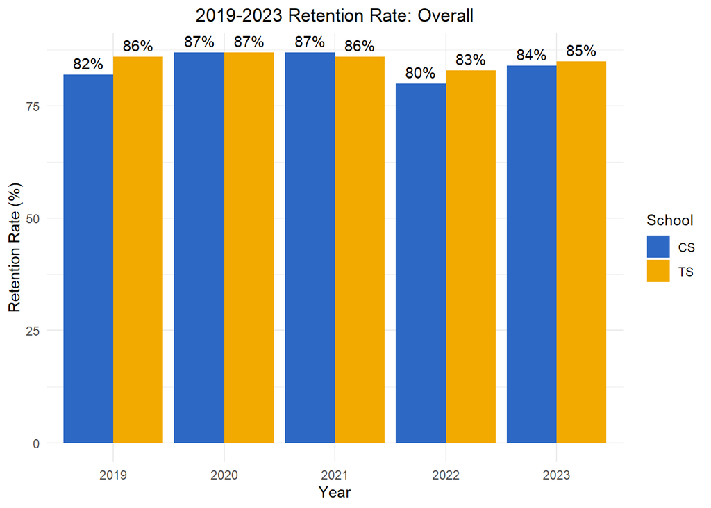

**Number of CS:** 34

**Number of TS:** 88

### Teachers of Color

| School | 2019 | 2020 | 2021 | 2022 | 2023 |
| --- | --- | --- | --- | --- | --- |
| CS Overall Retention Rate | 83 | 87 | 87 | 80 | 85 |
| TS Overall Retention Rate | 87 | 88 | 86 | 84 | 86 |

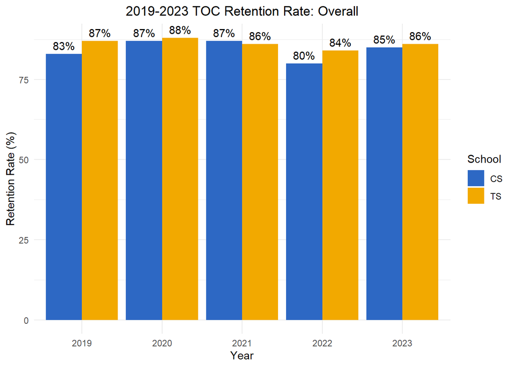

**Number of CS:** 34

**Number of TS:** 88

**Findings**: Overall retention rates between CS and TS are very similar from each other. There is a dip in retention during the 2022 year, which also corresponds following the physical school closures in LAUSD.

## Retention Rate: Elementary Schools

### All Teachers

| School | 2019 | 2020 | 2021 | 2022 | 2023 |
| --- | --- | --- | --- | --- | --- |
| CS Overall Retention Rate | 88 | 90 | 88 | 83 | 86 |
| TS Overall Retention Rate | 87 | 88 | 86 | 83 | 86 |

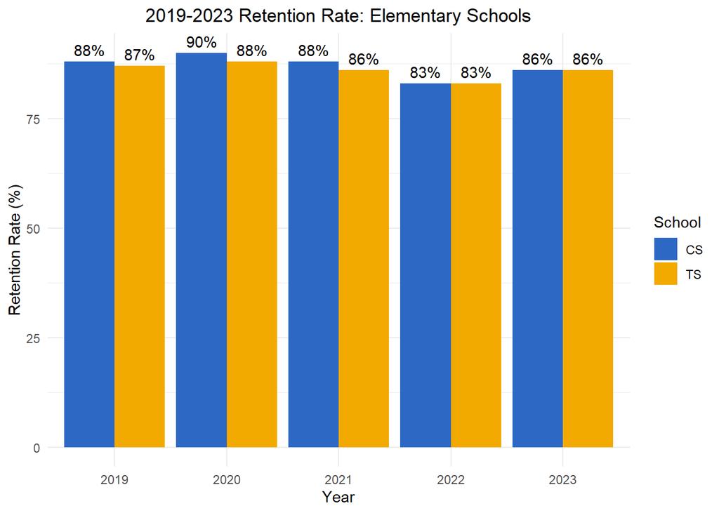

**Number of CS:** 22

**Number of TS:** 73

### Teachers of Color

| School | 2019 | 2020 | 2021 | 2022 | 2023 |
| --- | --- | --- | --- | --- | --- |
| CS Overall Retention Rate | 87 | 91 | 88 | 83 | 87 |
| TS Overall Retention Rate | 88 | 88 | 86 | 84 | 87 |

[figure not shown]

**Number of CS:** 22

**Number of TS:** 73

**Findings**: Overall retention rates between CS and TS elementary schools are very similar from each other.

## Retention: Middle/High Schools

### All Teachers

| School | 2019 | 2020 | 2021 | 2022 | 2023 |
| --- | --- | --- | --- | --- | --- |
| CS Overall Retention Rate | 73 | 82 | 86 | 76 | 81 |
| TS Overall Retention Rate | 78 | 81 | 85 | 79 | 77 |

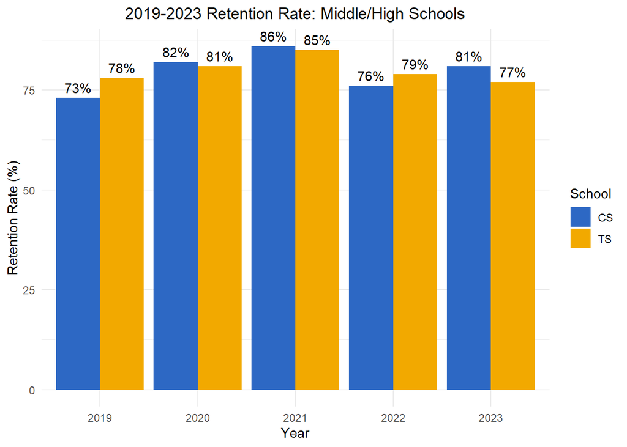

**Number of CS:** 12

**Number of TS:** 13

**Findings**: Overall retention rates between CS and TS Middle/High schools are very similar from each other.

### Teachers of Color

| School | 2019 | 2020 | 2021 | 2022 | 2023 |
| --- | --- | --- | --- | --- | --- |
| CS Overall Retention Rate | 75 | 82 | 85 | 75 | 82 |
| TS Overall Retention Rate | 77 | 82 | 85 | 80 | 81 |

[figure not shown]

**Number of CS:** 12

**Number of TS:** 12

**Findings**: Overall retention rates between CS and TS Middle/High schools are very similar from each other.

## Retention by Teacher Veteran Status (Teachers of Color)

**Main Finding**: Community Schools seem to have a higher retention rate among young teachers (0-5 years) compared to Traditional Public Schools. Among veteran teachers, retention rate between CS and TS are comparable.

### Count of Teachers

**Main Finding**: Looking at the teacher count by veteran status. Veteran teachers (over 15 years teaching) is the largest group followed by the most junior cohort (5 or less years of teaching). The 6-10 and 11-15 year categories have the least number of teachers. This could suggest that many young teachers leave within the first 5 years.

**Teacher Count in 2018-2019**

| School Type | 0-5 years | 6-10 years | 11-15 years | 15+ years |
| --- | --- | --- | --- | --- |
| cs | 190 | 67 | 136 | 664 |
| ts | 486 | 137 | 308 | 1692 |

**Teacher Count in 2019-2020**

| School Type | 0-5 years | 6-10 years | 11-15 years | 15+ years |
| --- | --- | --- | --- | --- |
| cs | 180 | 78 | 117 | 671 |
| ts | 471 | 141 | 248 | 1665 |

**Teacher Count in 2020-2021**

| School Type | 0-5 years | 6-10 years | 11-15 years | 15+ years |
| --- | --- | --- | --- | --- |
| cs | 193 | 92 | 113 | 659 |
| ts | 450 | 192 | 209 | 1652 |

**Teacher Count in 2021-2022**

| School Type | 0-5 years | 6-10 years | 11-15 years | 15+ years |
| --- | --- | --- | --- | --- |
| cs | 229 | 104 | 102 | 685 |
| ts | 401 | 221 | 156 | 1664 |

**Teacher Count in 2022-2023**

| School Type | 0-5 years | 6-10 years | 11-15 years | 15+ years |
| --- | --- | --- | --- | --- |
| cs | 236 | 118 | 75 | 691 |
| ts | 421 | 222 | 124 | 1670 |

**Teacher Count in 2023-2024**

| School Type | 0-5 years | 6-10 years | 11-15 years | 15+ years |
| --- | --- | --- | --- | --- |
| cs | 292 | 139 | 62 | 712 |
| ts | 453 | 245 | 123 | 1674 |

### 0-5 Years Teaching Experience

**All Schools**

| School | 2019 | 2020 | 2021 | 2022 | 2023 |
| --- | --- | --- | --- | --- | --- |
| CS Overall Retention Rate | 53 | 68 | 67 | 66 | 75 |
| TS Overall Retention Rate | 55 | 57 | 62 | 58 | 67 |

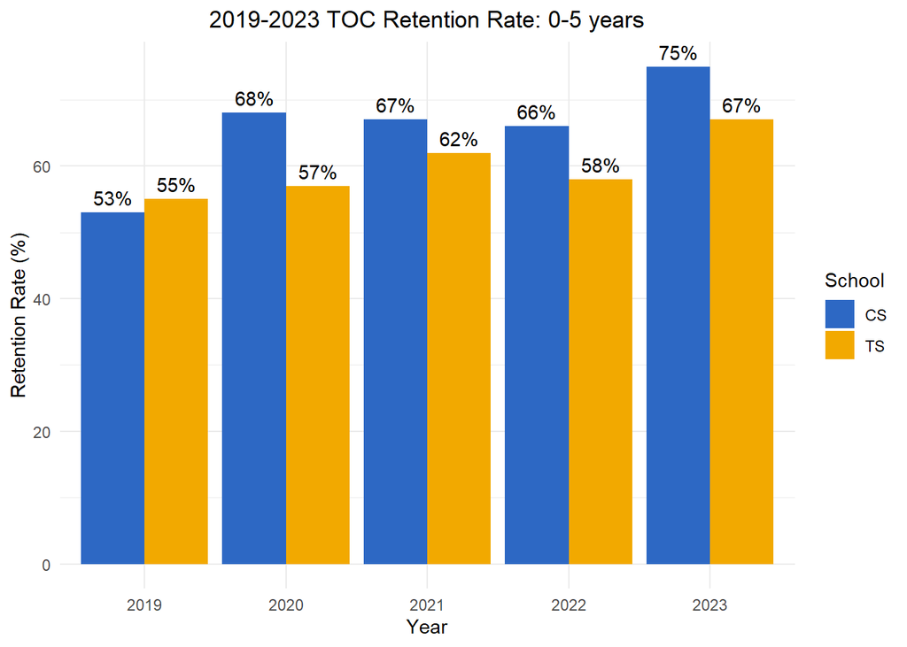

### 6-10 Years Teaching Experience

**All Schools**

| School | 2019 | 2020 | 2021 | 2022 | 2023 |
| --- | --- | --- | --- | --- | --- |
| CS Overall Retention Rate | 52 | 62 | 76 | 67 | 67 |
| TS Overall Retention Rate | 47 | 57 | 61 | 61 | 69 |

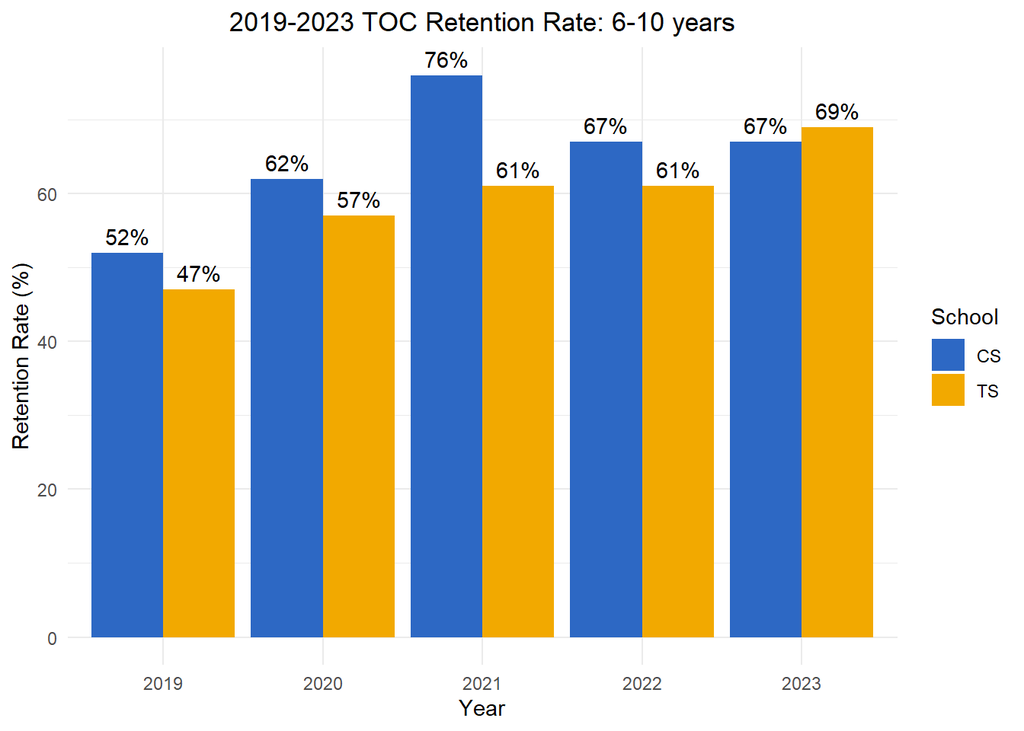

### 11-15 Years Teaching Experience

**All Schools**

| School | 2019 | 2020 | 2021 | 2022 | 2023 |
| --- | --- | --- | --- | --- | --- |
| CS Overall Retention Rate | 66 | 70 | 74 | 67 | 64 |
| TS Overall Retention Rate | 77 | 70 | 66 | 62 | 56 |

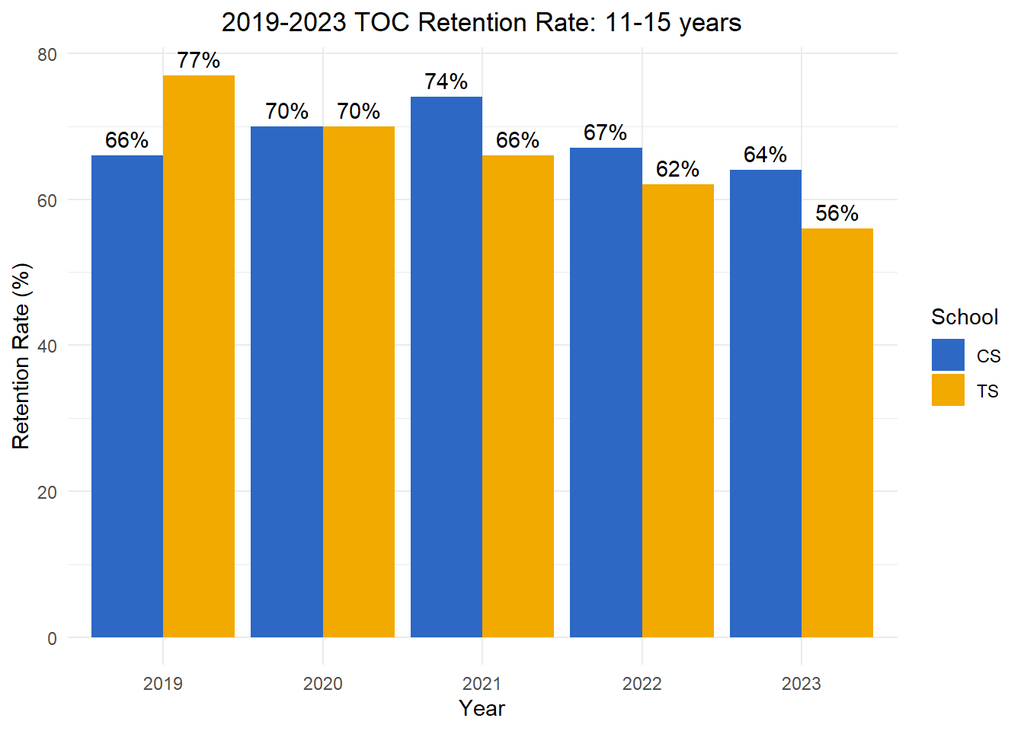

### 15+ Years Teaching Experience

**All Schools**

| School | 2019 | 2020 | 2021 | 2022 | 2023 |
| --- | --- | --- | --- | --- | --- |
| CS Overall Retention Rate | 84 | 87 | 85 | 83 | 86 |
| TS Overall Retention Rate | 88 | 89 | 87 | 86 | 89 |

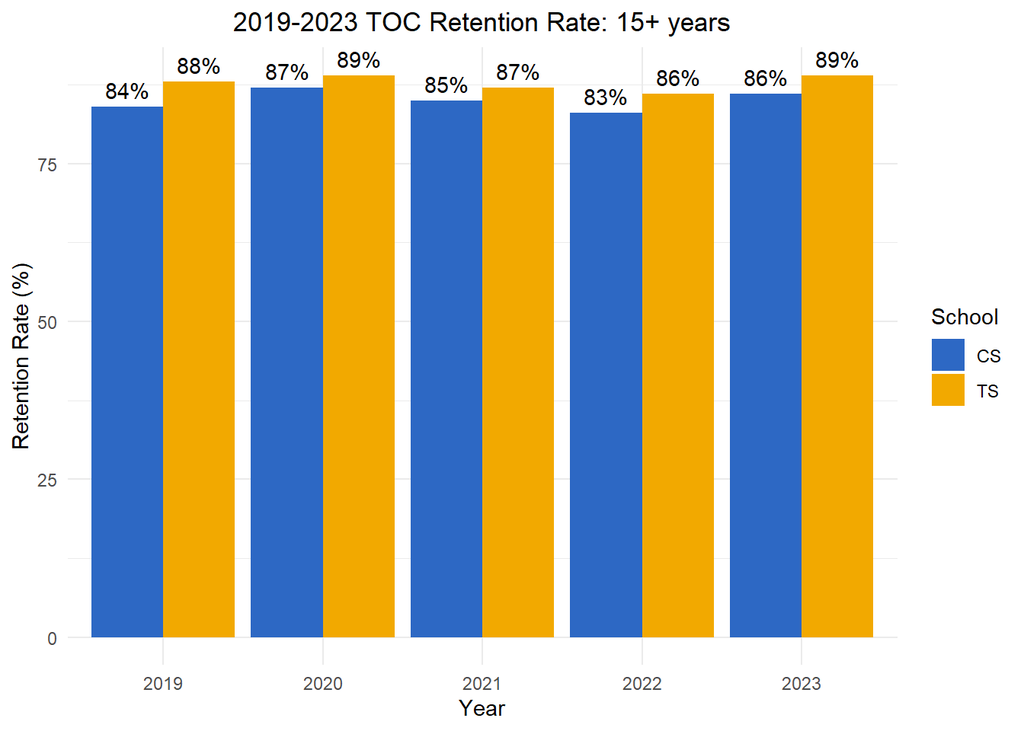

## Retention: By Neighborhood

**Main Finding:** Teacher Retention among Community Schools varies by neighborhood.

In some neighborhoods, teacher retention is higher in Community Schools compared to the teacher retention of traditional public schools in the area.

For example, see **Boyle Heights:**

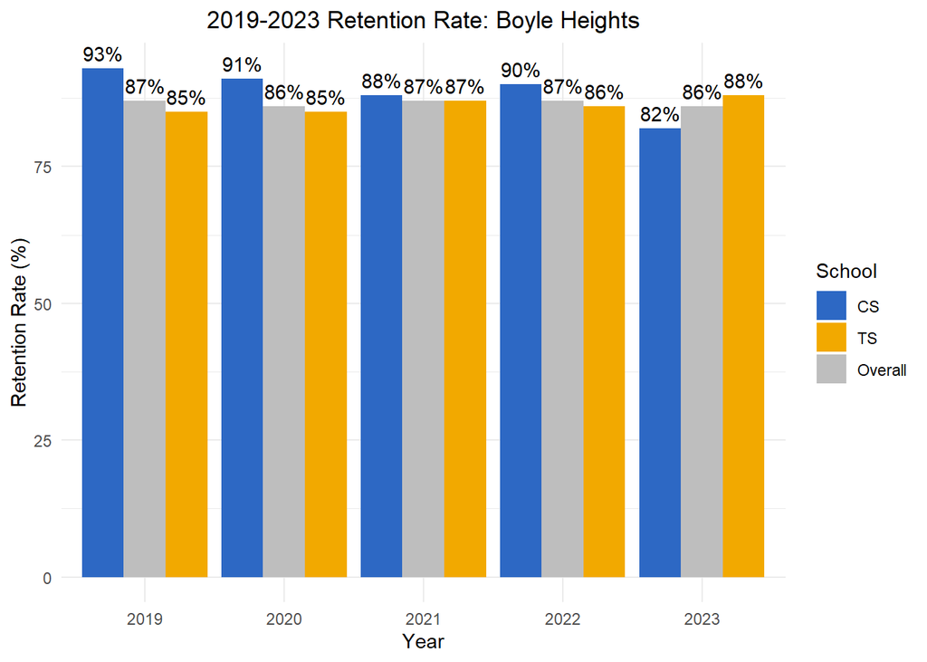

**Number of CS:** 2

**Number of TS:** 6

**Overall Combined Table**

| School | 2019 | 2020 | 2021 | 2022 | 2023 |
| --- | --- | --- | --- | --- | --- |
| CS Overall Retention Rate | 93 | 91 | 88 | 90 | 82 |
| TS Overall Retention Rate | 85 | 85 | 87 | 86 | 88 |
| Combined Overall Retention Rate | 87 | 86 | 87 | 87 | 86 |

In other neighborhoods, teacher retention between Community Schools and Traditional Public Schools are similar to each other.

An example of this is the **Monroe** neighborhood:

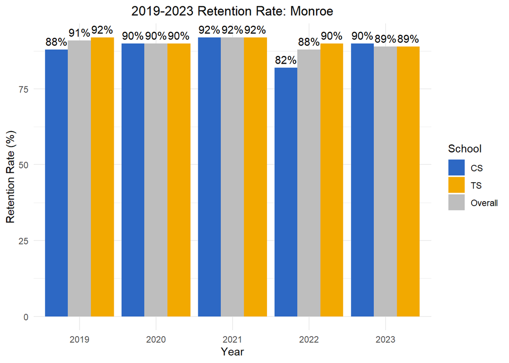

**Number of CS:** 2

**Number of TS:** 6

**Overall Combined Table**

| School | 2019 | 2020 | 2021 | 2022 | 2023 |
| --- | --- | --- | --- | --- | --- |
| CS Overall Retention Rate | 88 | 90 | 92 | 82 | 90 |
| TS Overall Retention Rate | 92 | 90 | 92 | 90 | 89 |
| Combined Overall Retention Rate | 91 | 90 | 92 | 88 | 89 |

Lastly, in other neighborhoods, teacher retention in Community Schools is lower than Traditional Public Schools.

An example of this is the **MacArthur Park** neighborhood:

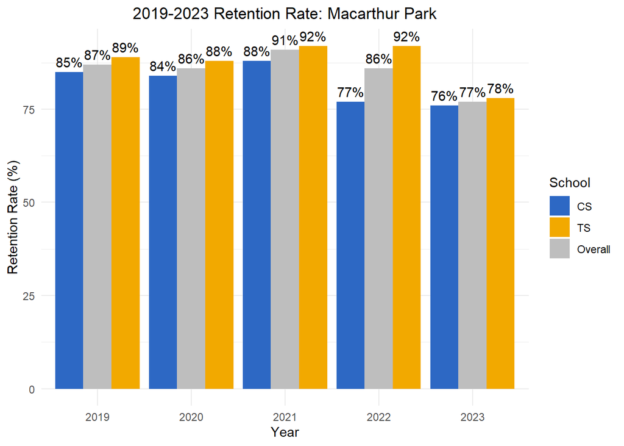

**Number of CS:** 2

**Number of TS:** 3

**Overall Combined Table**

| School | 2019 | 2020 | 2021 | 2022 | 2023 |
| --- | --- | --- | --- | --- | --- |
| CS Overall Retention Rate | 85 | 84 | 88 | 77 | 76 |
| TS Overall Retention Rate | 89 | 88 | 92 | 92 | 78 |
| Combined Overall Retention Rate | 87 | 86 | 91 | 86 | 77 |

# Appendix

## Community School Retention Rate

### CS: Overall

| School | 2019 | 2020 | 2021 | 2022 | 2023 |
| --- | --- | --- | --- | --- | --- |
| 74th Street Elementary | 86% (21) | 95% (19) | 78% (18) | 75% (20) | 91% (22) |
| 93rd Street Elementary | 88% (41) | 85% (41) | 84% (43) | 83% (41) | 80% (41) |
| Alta California Elementary | 80% (35) | 93% (29) | 93% (27) | 76% (29) | 83% (35) |
| Alta Loma Elementary | 92% (26) | 92% (25) | 100% (24) | 85% (26) | 97% (29) |
| Audubon Middle School | 57% (30) | 83% (24) | 79% (24) | 57% (28) | 76% (29) |
| Augustus Hawkins Senior High | 85% (34) | 76% (34) | 79% (28) | 54% (56) | 78% (45) |
| Baldwin Hills Elementary | 93% (14) | 93% (14) | 80% (15) | 71% (17) | 72% (18) |
| Carlos Santana Arts Academy | 96% (23) | 87% (23) | 92% (24) | 88% (25) | 96% (26) |
| Carver MS | NaN% (0) | 72% (36) | 86% (36) | 77% (39) | 79% (39) |
| Catskill Avenue Elementary | 96% (27) | 92% (26) | 93% (27) | 96% (27) | 94% (31) |
| Ellen Ochoa Learning Center | 91% (65) | 94% (65) | 91% (65) | 88% (69) | 91% (69) |
| Euclid Avenue Elementary | 90% (29) | 87% (31) | 84% (32) | 92% (36) | 84% (37) |
| Farmdale Elementary | 81% (31) | 85% (27) | 91% (23) | 83% (23) | 100% (20) |
| Felicitas And Gonzalo Mendez Senior High | 96% (57) | 95% (57) | 93% (55) | 88% (58) | 79% (56) |
| Gardner Street Elementary | 94% (17) | 82% (17) | 80% (15) | 61% (18) | 75% (12) |
| Hillcrest Drive Elementary | 82% (28) | 96% (26) | 89% (28) | 78% (27) | 81% (27) |
| John H Francis Polytechnic Senior High | 92% (112) | 93% (110) | 95% (107) | 85% (110) | 91% (109) |
| Logan Academy of Global Ecology | 77% (22) | 82% (22) | 75% (24) | 85% (27) | 89% (27) |
| Lucille Roybal-Allard Elementary | 84% (31) | 93% (28) | 100% (26) | 83% (29) | 96% (26) |
| Marina Del Rey Middle School | 88% (17) | 72% (18) | 88% (17) | 76% (17) | 72% (18) |
| Miguel Contreras Learning Complex - Acdemic Ldrshp Community | 76% (25) | 91% (22) | 83% (23) | 75% (24) | 69% (26) |
| Miguel Contreras Learning Complex - LA Sch of Global Studies | 94% (17) | 76% (17) | 94% (18) | 79% (19) | 83% (18) |
| Miramonte Elementary | 95% (39) | 90% (39) | 90% (41) | 82% (40) | 90% (48) |
| Palms Elementary | 90% (20) | 100% (20) | 80% (20) | 85% (20) | 86% (21) |
| Panorama Senior High | 64% (56) | 83% (53) | 86% (58) | 70% (57) | 80% (59) |
| Purche Avenue Elementary | 84% (19) | 83% (18) | 89% (18) | 76% (21) | 72% (25) |
| Sharp Avenue Elementary | 81% (36) | 94% (33) | 91% (32) | 84% (32) | 82% (33) |
| Susan Miller Dorsey Senior High | 63% (41) | 76% (37) | 88% (33) | 75% (40) | 80% (40) |
| Trinity Street Elementary | 78% (18) | 87% (15) | 81% (16) | 94% (16) | 83% (18) |
| Van Nuys Elementary | 94% (35) | 94% (33) | 91% (33) | 83% (35) | 93% (30) |
| Venice Senior High | 79% (52) | 88% (50) | 74% (54) | 91% (54) | 90% (60) |
| Vine Street Elementary | 85% (26) | 82% (22) | 85% (20) | 84% (19) | 83% (24) |
| Walnut Park Elementary | 88% (34) | 94% (33) | 94% (33) | 86% (35) | 78% (40) |
| Woodrow Wilson Senior High | 86% (56) | 82% (56) | 93% (57) | 84% (67) | 91% (65) |
| Overall Retention Rate % | 82% | 87% | 87% | 80% | 84% |

**Note:** The numbers in the parentheses represents the number of teachers in that schools for the previous school year. For instance, (39) in the 2019 column says that there are 39 teachers in the 2018-2019 school year.

### CS: Elementary Schools

| School | 2019 | 2020 | 2021 | 2022 | 2023 |
| --- | --- | --- | --- | --- | --- |
| 74th Street Elementary | 86 | 95 | 78 | 75 | 91 |
| 93rd Street Elementary | 88 | 85 | 84 | 83 | 80 |
| Alta California Elementary | 80 | 93 | 93 | 76 | 83 |
| Alta Loma Elementary | 92 | 92 | 100 | 85 | 97 |
| Baldwin Hills Elementary | 93 | 93 | 80 | 71 | 72 |
| Carlos Santana Arts Academy | 96 | 87 | 92 | 88 | 96 |
| Catskill Avenue Elementary | 96 | 92 | 93 | 96 | 94 |
| Ellen Ochoa Learning Center | 91 | 94 | 91 | 88 | 91 |
| Euclid Avenue Elementary | 90 | 87 | 84 | 92 | 84 |
| Farmdale Elementary | 81 | 85 | 91 | 83 | 100 |
| Gardner Street Elementary | 94 | 82 | 80 | 61 | 75 |
| Hillcrest Drive Elementary | 82 | 96 | 89 | 78 | 81 |
| Logan Academy of Global Ecology | 77 | 82 | 75 | 85 | 89 |
| Lucille Roybal-Allard Elementary | 84 | 93 | 100 | 83 | 96 |
| Miramonte Elementary | 95 | 90 | 90 | 82 | 90 |
| Palms Elementary | 90 | 100 | 80 | 85 | 86 |
| Purche Avenue Elementary | 84 | 83 | 89 | 76 | 72 |
| Sharp Avenue Elementary | 81 | 94 | 91 | 84 | 82 |
| Trinity Street Elementary | 78 | 87 | 81 | 94 | 83 |
| Van Nuys Elementary | 94 | 94 | 91 | 83 | 93 |
| Vine Street Elementary | 85 | 82 | 85 | 84 | 83 |
| Walnut Park Elementary | 88 | 94 | 94 | 86 | 78 |
| Overall Retention Rate % | 88 | 90 | 88 | 83 | 86 |

### CS: Middle/High Schools

| School | 2019 | 2020 | 2021 | 2022 | 2023 |
| --- | --- | --- | --- | --- | --- |
| Audubon Middle School | 57 | 83 | 79 | 57 | 76 |
| Augustus Hawkins Senior High | 85 | 76 | 79 | 54 | 78 |
| Carver MS | NaN | 72 | 86 | 77 | 79 |
| Felicitas And Gonzalo Mendez Senior High | 96 | 95 | 93 | 88 | 79 |
| John H Francis Polytechnic Senior High | 92 | 93 | 95 | 85 | 91 |
| Marina Del Rey Middle School | 88 | 72 | 88 | 76 | 72 |
| Miguel Contreras Learning Complex - Acdemic Ldrshp Community | 76 | 91 | 83 | 75 | 69 |
| Miguel Contreras Learning Complex - LA Sch of Global Studies | 94 | 76 | 94 | 79 | 83 |
| Panorama Senior High | 64 | 83 | 86 | 70 | 80 |
| Susan Miller Dorsey Senior High | 63 | 76 | 88 | 75 | 80 |
| Venice Senior High | 79 | 88 | 74 | 91 | 90 |
| Woodrow Wilson Senior High | 86 | 82 | 93 | 84 | 91 |
| Overall Retention Rate % | 73 | 82 | 86 | 76 | 81 |

## Traditional Public Schools Retention Rate

**Main Finding:** There is a large variance among retention rates among Traditional Schools. This is true among Elementary, Middle, and High Schools.

### TS: Overall

| School | 2019 | 2020 | 2021 | 2022 | 2023 |
| --- | --- | --- | --- | --- | --- |
| 107th Street Elementary | 81 | 86 | 79 | 89 | 84 |
| 153rd Street Elementary | 88 | 85 | 88 | 68 | 90 |
| 1st Street Elementary | 82 | 87 | 88 | 84 | 85 |
| 28th Street Elementary | 91 | 97 | 97 | 88 | 100 |
| 2nd Street Elementary | 80 | 88 | 94 | 75 | 88 |
| 42nd Street Elementary | 58 | 54 | 71 | 75 | 75 |
| 54th Street Elementary | 59 | 76 | 82 | 67 | 68 |
| 59th Street Elementary | 88 | 78 | 80 | 58 | 88 |
| 66th Street Elementary | 92 | 86 | 82 | 92 | 92 |
| 75th Street Elementary | 87 | 73 | 87 | 86 | 85 |
| 99th Street Elementary | 79 | 91 | 71 | 77 | 69 |
| 9th Street Elementary | 100 | 89 | 69 | 69 | 88 |
| Abraham Lincoln Senior High | 83 | 89 | 92 | 80 | 80 |
| Amestoy Elementary | 93 | 100 | 87 | 85 | 100 |
| Arleta Senior High | 94 | 92 | 88 | 84 | 97 |
| Arlington Heights Elementary | 91 | 86 | 94 | 81 | 81 |
| Arminta Street Elementary | 83 | 83 | 100 | 88 | 100 |
| Beachy Avenue Elementary | 85 | 100 | 89 | 85 | 82 |
| Bonita Street Elementary | 88 | 95 | 87 | 92 | 80 |
| Cal Burke High School | 100 | 75 | 100 | 88 | 88 |
| Carmen Lomas Garza Primary Center | 78 | 86 | 86 | 88 | 89 |
| Caroldale Learning Community | 95 | 89 | 89 | 90 | 82 |
| Chapman Elementary | 91 | 95 | 90 | 95 | 90 |
| Charnock Road Elementary | 90 | 71 | 80 | 80 | 91 |
| Chase Street Elementary | 100 | 87 | 93 | 93 | 93 |
| Cheremoya Avenue Elementary | 86 | 73 | 85 | 57 | 70 |
| Cienega Elementary | 84 | 87 | 100 | 81 | 78 |
| Coliseum Street Elementary | 80 | 100 | 83 | 85 | 87 |
| Columbus Avenue Elementary | 74 | 100 | 72 | 86 | 88 |
| Corona Avenue Elementary | 92 | 90 | 86 | 85 | 85 |

[output cut: 59 more lines]

### TS: Elementary Schools

| School | 2019 | 2020 | 2021 | 2022 | 2023 |
| --- | --- | --- | --- | --- | --- |
| 107th Street Elementary | 81 | 86 | 79 | 89 | 84 |
| 153rd Street Elementary | 88 | 85 | 88 | 68 | 90 |
| 1st Street Elementary | 82 | 87 | 88 | 84 | 85 |
| 28th Street Elementary | 91 | 97 | 97 | 88 | 100 |
| 2nd Street Elementary | 80 | 88 | 94 | 75 | 88 |
| 42nd Street Elementary | 58 | 54 | 71 | 75 | 75 |
| 54th Street Elementary | 59 | 76 | 82 | 67 | 68 |
| 59th Street Elementary | 88 | 78 | 80 | 58 | 88 |
| 66th Street Elementary | 92 | 86 | 82 | 92 | 92 |
| 75th Street Elementary | 87 | 73 | 87 | 86 | 85 |
| 99th Street Elementary | 79 | 91 | 71 | 77 | 69 |
| 9th Street Elementary | 100 | 89 | 69 | 69 | 88 |
| Amestoy Elementary | 93 | 100 | 87 | 85 | 100 |
| Arlington Heights Elementary | 91 | 86 | 94 | 81 | 81 |
| Arminta Street Elementary | 83 | 83 | 100 | 88 | 100 |
| Beachy Avenue Elementary | 85 | 100 | 89 | 85 | 82 |
| Bonita Street Elementary | 88 | 95 | 87 | 92 | 80 |
| Carmen Lomas Garza Primary Center | 78 | 86 | 86 | 88 | 89 |
| Caroldale Learning Community | 95 | 89 | 89 | 90 | 82 |
| Chapman Elementary | 91 | 95 | 90 | 95 | 90 |
| Charnock Road Elementary | 90 | 71 | 80 | 80 | 91 |
| Chase Street Elementary | 100 | 87 | 93 | 93 | 93 |
| Cheremoya Avenue Elementary | 86 | 73 | 85 | 57 | 70 |
| Cienega Elementary | 84 | 87 | 100 | 81 | 78 |
| Coliseum Street Elementary | 80 | 100 | 83 | 85 | 87 |
| Columbus Avenue Elementary | 74 | 100 | 72 | 86 | 88 |
| Corona Avenue Elementary | 92 | 90 | 86 | 85 | 85 |
| Denker Avenue Elementary | 97 | 97 | 90 | 86 | 95 |
| Dolores Street Elementary | 94 | 93 | 93 | 92 | 93 |
| El Sereno Elementary | 83 | 88 | 81 | 94 | 75 |
| Erwin Elementary | 89 | 97 | 94 | 94 | 94 |
| Fernangeles Elementary | 91 | 87 | 91 | 94 | 89 |
| Figueroa Street Elementary | 87 | 95 | 95 | 83 | 96 |
| Florence Avenue Elementary | 90 | 88 | 88 | 94 | 94 |
| Florence Griffith Joyner Elementary | 85 | 76 | 83 | 48 | 74 |
| Frank Del Olmo Elementary | 85 | 94 | 83 | 82 | 74 |
| Harvard Elementary | 78 | 71 | 82 | 95 | 68 |
| Hazeltine Avenue Elementary | 74 | 80 | 76 | 90 | 67 |
| Hollywood Elementary | 85 | 85 | 75 | 84 | 89 |
| Hope Street Elementary | 92 | 88 | 96 | 92 | 77 |
| Huntington Park Elementary | 100 | 100 | 89 | 95 | 81 |
| Jaime Escalante Elementary School | 96 | 92 | 88 | 86 | 89 |
| Julie Korenstein Elementary | 91 | 95 | 80 | 80 | 84 |
| Kittridge Street Elementary | 83 | 87 | 85 | 97 | 88 |
| Langdon Avenue Elementary | 94 | 91 | 94 | 91 | 91 |
| Liggett Street Elementary | 92 | 91 | 89 | 88 | 86 |
| Loma Vista Elementary | 92 | 95 | 94 | 89 | 97 |
| Malabar Street Elementary | 93 | 86 | 77 | 82 | 87 |
| Manhattan Place Elementary | 63 | 65 | 77 | 56 | 62 |
| McKinley Avenue Elementary | 95 | 89 | 81 | 88 | 89 |
| Middleton Street Elementary | 93 | 100 | 91 | 86 | 86 |
| Miles Avenue Elementary | 95 | 86 | 95 | 90 | 91 |
| Multnomah Street Elementary | 61 | 91 | 82 | 55 | 83 |
| Panorama City Elementary | 93 | 96 | 93 | 81 | 82 |
| Parmelee Avenue Elementary | 93 | 88 | 97 | 92 | 92 |
| Plummer Elementary | 88 | 88 | 90 | 90 | 91 |
| Ricardo Lizarraga Elementary | 82 | 93 | 82 | 84 | 94 |
| Rosa Parks Learning Center | 88 | 84 | 93 | 97 | 92 |
| Rosemont Avenue Elementary | 80 | 87 | 60 | 50 | 82 |
| Russell Elementary | 92 | 95 | 74 | 83 | 94 |
| San Antonio Elementary | 78 | 88 | 92 | 88 | 84 |
| Shenandoah Street Elementary | 96 | 88 | 73 | 86 | 95 |
| Sierra Park Elementary | 90 | 90 | 73 | 95 | 86 |
| Soto Street Elementary | 87 | 94 | 82 | 94 | 89 |
| South Park Elementary | 93 | 89 | 91 | 88 | 96 |
| Sylvan Park Elementary | 86 | 95 | 88 | 83 | 88 |
| Van Ness Avenue Elementary | 79 | 73 | 93 | 87 | 81 |
| Virginia Road Elementary | 78 | 73 | 93 | 62 | 87 |
| Wadsworth Avenue Elementary | 89 | 97 | 92 | 94 | 86 |
| West Vernon Avenue Elementary | 100 | 89 | 94 | 74 | 89 |
| Wisdom Elementary | 95 | 98 | 88 | 90 | 92 |
| Woodlawn Avenue Elementary | 94 | 97 | 97 | 92 | 84 |
| Young Empowered Scholars Academy | 88 | 78 | 85 | 75 | 77 |
| Overall Retention Rate % | 87 | 88 | 86 | 83 | 86 |

### TS: Middle/High Schools

| School | 2019 | 2020 | 2021 | 2022 | 2023 |
| --- | --- | --- | --- | --- | --- |
| Abraham Lincoln Senior High | 83 | 89 | 92 | 80 | 80 |
| Arleta Senior High | 94 | 92 | 88 | 84 | 97 |
| Cal Burke High School | 100 | 75 | 100 | 88 | 88 |
| George Washington Carver Middle School | 0 | NaN | NaN | NaN | NaN |
| Glenn Hammond Curtiss Middle School | 58 | 92 | 92 | 67 | 80 |
| Harold McAlister High School CYESIS | 90 | 78 | 100 | 90 | 67 |
| Los Angeles Academy Middle School | 82 | 91 | 95 | 79 | 83 |
| Mark Twain Middle School | 93 | 90 | 82 | 89 | 82 |
| Miguel Contreras Learning Complex - Business and Tourism | 81 | 95 | 90 | 95 | 87 |
| Miguel Contreras Learning Complex - School of Social Justice | 95 | 90 | 86 | 91 | 79 |
| Orchard Academies 2B | 76 | 100 | 96 | 92 | 85 |
| Orchard Academies 2C | 74 | 94 | 85 | 79 | 86 |
| Theodore Roosevelt Senior High | 88 | 68 | 95 | 93 | 89 |
| Overall Retention Rate % | 78 | 81 | 85 | 79 | 77 |

## By Neighborhood Analyses

### Hamilton

#### Overall

| School | 2019 | 2020 | 2021 | 2022 | 2023 |
| --- | --- | --- | --- | --- | --- |
| Baldwin Hills Elementary | 93 | 93 | 80 | 71 | 72 |
| Charnock Road Elementary | 90 | 71 | 80 | 80 | 91 |
| Palms Elementary | 90 | 100 | 80 | 85 | 86 |
| Shenandoah Street Elementary | 96 | 88 | 73 | 86 | 95 |
| Overall Retention Rate % | 92 | 88 | 78 | 80 | 86 |

#### CS

| School | 2019 | 2020 | 2021 | 2022 | 2023 |
| --- | --- | --- | --- | --- | --- |
| Baldwin Hills Elementary | 93 | 93 | 80 | 71 | 72 |
| Palms Elementary | 90 | 100 | 80 | 85 | 86 |
| Overall Retention Rate % | 92 | 96 | 80 | 78 | 79 |

#### TS

| School | 2019 | 2020 | 2021 | 2022 | 2023 |
| --- | --- | --- | --- | --- | --- |
| Charnock Road Elementary | 90 | 71 | 80 | 80 | 91 |
| Shenandoah Street Elementary | 96 | 88 | 73 | 86 | 95 |
| Overall Retention Rate % | 93 | 80 | 76 | 83 | 93 |

#### Graph

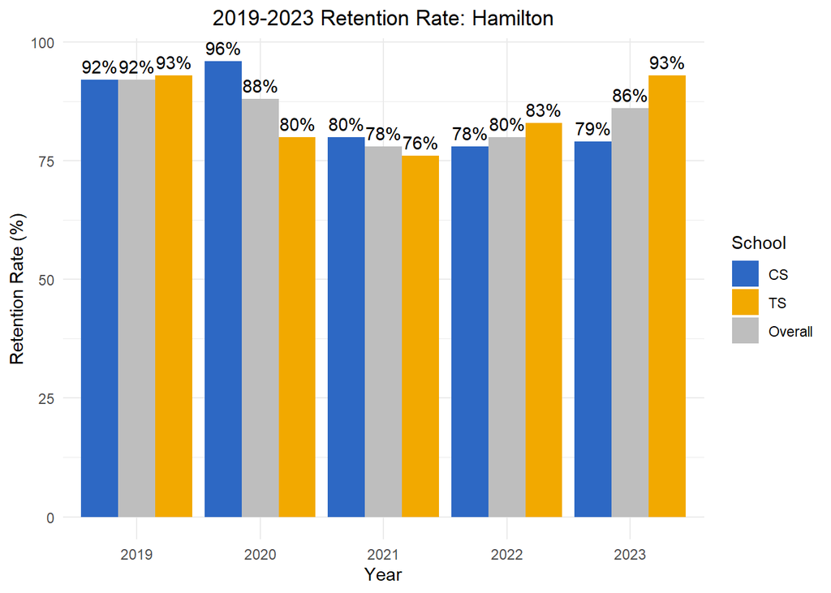

**Number of CS:** 2

**Number of TS:** 2

**Overall Combined Table**

[output not shown]

### Monroe

#### Overall

| School | 2019 | 2020 | 2021 | 2022 | 2023 |
| --- | --- | --- | --- | --- | --- |
| Alta California Elementary | 80 | 93 | 93 | 76 | 83 |
| Carlos Santana Arts Academy | 96 | 87 | 92 | 88 | 96 |
| Chase Street Elementary | 100 | 87 | 93 | 93 | 93 |
| Langdon Avenue Elementary | 94 | 91 | 94 | 91 | 91 |
| Liggett Street Elementary | 92 | 91 | 89 | 88 | 86 |
| Panorama City Elementary | 93 | 96 | 93 | 81 | 82 |
| Plummer Elementary | 88 | 88 | 90 | 90 | 91 |
| Rosa Parks Learning Center | 88 | 84 | 93 | 97 | 92 |
| Overall Retention Rate % | 91 | 90 | 92 | 88 | 89 |

#### CS

| School | 2019 | 2020 | 2021 | 2022 | 2023 |
| --- | --- | --- | --- | --- | --- |
| Alta California Elementary | 80 | 93 | 93 | 76 | 83 |
| Carlos Santana Arts Academy | 96 | 87 | 92 | 88 | 96 |
| Overall Retention Rate % | 88 | 90 | 92 | 82 | 90 |

#### TS

| School | 2019 | 2020 | 2021 | 2022 | 2023 |
| --- | --- | --- | --- | --- | --- |
| Chase Street Elementary | 100 | 87 | 93 | 93 | 93 |
| Langdon Avenue Elementary | 94 | 91 | 94 | 91 | 91 |
| Liggett Street Elementary | 92 | 91 | 89 | 88 | 86 |
| Panorama City Elementary | 93 | 96 | 93 | 81 | 82 |
| Plummer Elementary | 88 | 88 | 90 | 90 | 91 |
| Rosa Parks Learning Center | 88 | 84 | 93 | 97 | 92 |
| Overall Retention Rate % | 92 | 90 | 92 | 90 | 89 |

#### Graph

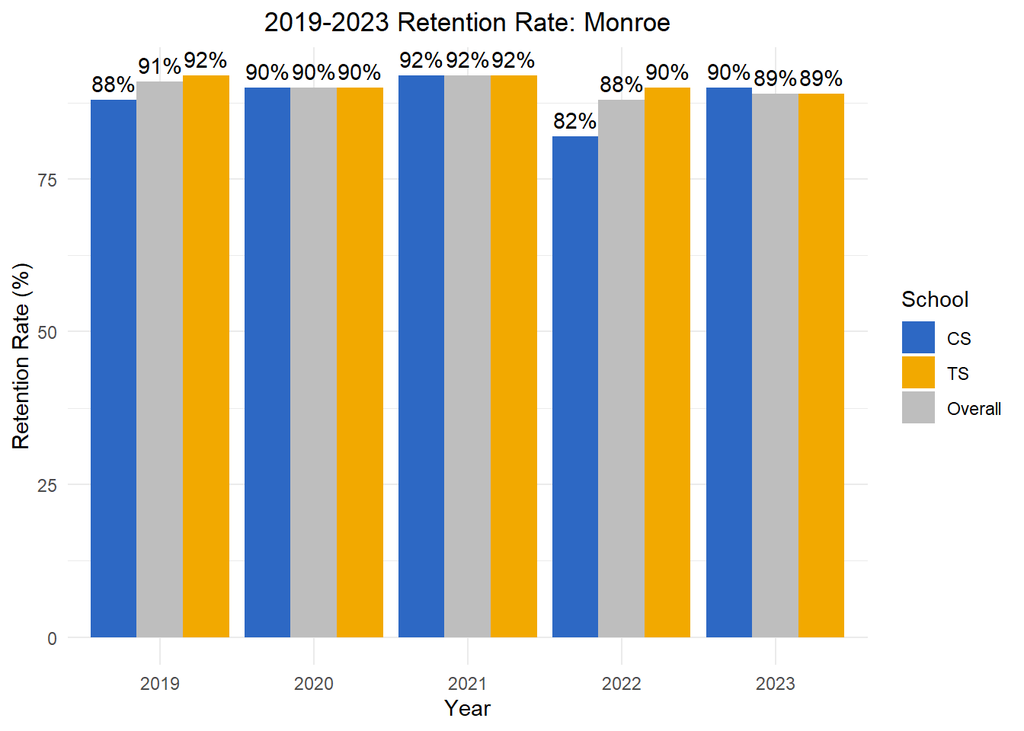

**Number of CS:** 2

**Number of TS:** 6

**Overall Combined Table**

| School | 2019 | 2020 | 2021 | 2022 | 2023 |
| --- | --- | --- | --- | --- | --- |
| CS Overall Retention Rate | 88 | 90 | 92 | 82 | 90 |
| TS Overall Retention Rate | 92 | 90 | 92 | 90 | 89 |
| Combined Overall Retention Rate | 91 | 90 | 92 | 88 | 89 |

### Bell Cuday Monroe

#### Overall

| School | 2019 | 2020 | 2021 | 2022 | 2023 |
| --- | --- | --- | --- | --- | --- |
| Corona Avenue Elementary | 92 | 90 | 86 | 85 | 85 |
| Elizabeth Learning Center | 90 | 92 | 95 | 91 | 91 |
| Ellen Ochoa Learning Center | 91 | 94 | 91 | 88 | 91 |
| Jaime Escalante Elementary School | 96 | 92 | 88 | 86 | 89 |
| Loma Vista Elementary | 92 | 95 | 94 | 89 | 97 |
| Orchard Academies 2B | 76 | 100 | 96 | 92 | 85 |
| Orchard Academies 2C | 74 | 94 | 85 | 79 | 86 |
| Woodlawn Avenue Elementary | 94 | 97 | 97 | 92 | 84 |
| Overall Retention Rate % | 88 | 94 | 92 | 88 | 88 |

#### CS

| School | 2019 | 2020 | 2021 | 2022 | 2023 |
| --- | --- | --- | --- | --- | --- |
| Ellen Ochoa Learning Center | 91 | 94 | 91 | 88 | 91 |
| Overall Retention Rate % | 91 | 94 | 91 | 88 | 91 |

#### TS

| School | 2019 | 2020 | 2021 | 2022 | 2023 |
| --- | --- | --- | --- | --- | --- |
| Corona Avenue Elementary | 92 | 90 | 86 | 85 | 85 |
| Elizabeth Learning Center | 90 | 92 | 95 | 91 | 91 |
| Jaime Escalante Elementary School | 96 | 92 | 88 | 86 | 89 |
| Loma Vista Elementary | 92 | 95 | 94 | 89 | 97 |
| Orchard Academies 2B | 76 | 100 | 96 | 92 | 85 |
| Orchard Academies 2C | 74 | 94 | 85 | 79 | 86 |
| Woodlawn Avenue Elementary | 94 | 97 | 97 | 92 | 84 |
| Overall Retention Rate % | 88 | 94 | 92 | 88 | 88 |

#### Graph

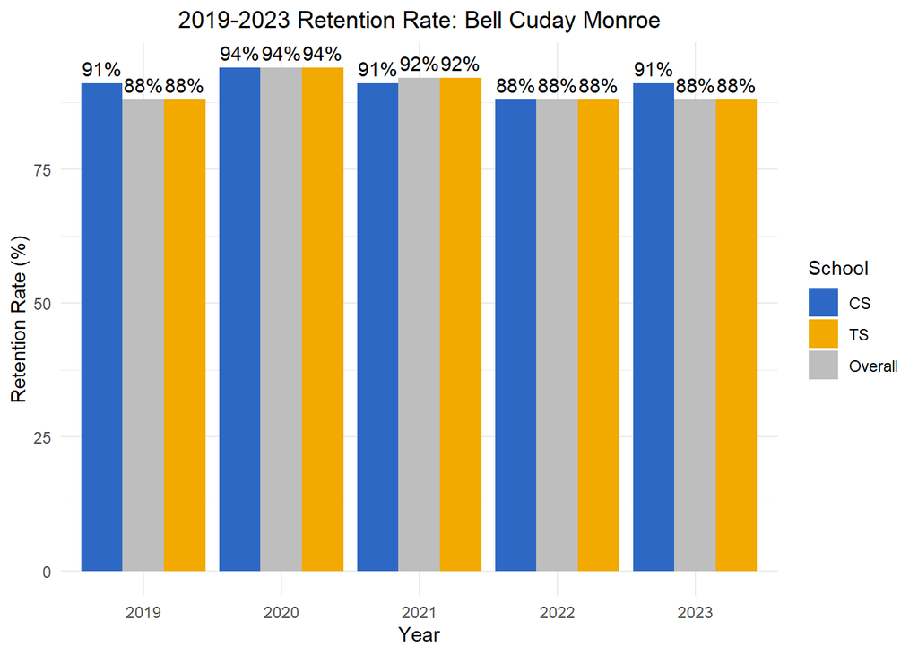

**Number of CS:** 1

**Number of TS:** 7

**Overall Combined Table**

[output not shown]

### Hollywood

#### Overall

| School | 2019 | 2020 | 2021 | 2022 | 2023 |
| --- | --- | --- | --- | --- | --- |
| Cheremoya Avenue Elementary | 86 | 73 | 85 | 57 | 70 |
| Gardner Street Elementary | 94 | 82 | 80 | 61 | 75 |
| Harvard Elementary | 78 | 71 | 82 | 95 | 68 |
| Hollywood Elementary | 85 | 85 | 75 | 84 | 89 |
| Van Ness Avenue Elementary | 79 | 73 | 93 | 87 | 81 |
| Vine Street Elementary | 85 | 82 | 85 | 84 | 83 |
| Overall Retention Rate % | 84 | 78 | 83 | 78 | 78 |

#### CS

| School | 2019 | 2020 | 2021 | 2022 | 2023 |
| --- | --- | --- | --- | --- | --- |
| Gardner Street Elementary | 94 | 82 | 80 | 61 | 75 |
| Vine Street Elementary | 85 | 82 | 85 | 84 | 83 |
| Overall Retention Rate % | 90 | 82 | 82 | 72 | 79 |

#### TS

| School | 2019 | 2020 | 2021 | 2022 | 2023 |
| --- | --- | --- | --- | --- | --- |
| Cheremoya Avenue Elementary | 86 | 73 | 85 | 57 | 70 |
| Harvard Elementary | 78 | 71 | 82 | 95 | 68 |
| Hollywood Elementary | 85 | 85 | 75 | 84 | 89 |
| Van Ness Avenue Elementary | 79 | 73 | 93 | 87 | 81 |
| Overall Retention Rate % | 82 | 76 | 84 | 81 | 77 |

#### Graph

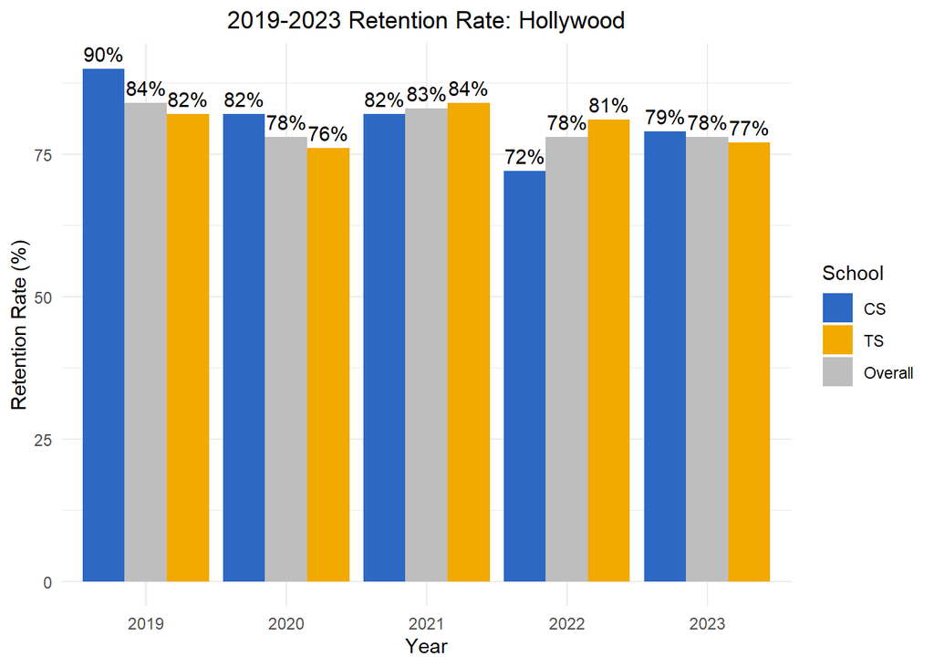

**Number of CS:** 2

**Number of TS:** 4

**Overall Combined Table**

[output not shown]

### LA Mid-City

#### Overall

| School | 2019 | 2020 | 2021 | 2022 | 2023 |
| --- | --- | --- | --- | --- | --- |
| 54th Street Elementary | 59 | 76 | 82 | 67 | 68 |
| Alta Loma Elementary | 92 | 92 | 100 | 85 | 97 |
| Arlington Heights Elementary | 91 | 86 | 94 | 81 | 81 |
| Cienega Elementary | 84 | 87 | 100 | 81 | 78 |
| Virginia Road Elementary | 78 | 73 | 93 | 62 | 87 |
| Overall Retention Rate % | 81 | 83 | 94 | 75 | 82 |

#### CS

| School | 2019 | 2020 | 2021 | 2022 | 2023 |
| --- | --- | --- | --- | --- | --- |
| Alta Loma Elementary | 92 | 92 | 100 | 85 | 97 |
| Overall Retention Rate % | 92 | 92 | 100 | 85 | 97 |

#### TS

| School | 2019 | 2020 | 2021 | 2022 | 2023 |
| --- | --- | --- | --- | --- | --- |
| 54th Street Elementary | 59 | 76 | 82 | 67 | 68 |
| Arlington Heights Elementary | 91 | 86 | 94 | 81 | 81 |
| Cienega Elementary | 84 | 87 | 100 | 81 | 78 |
| Virginia Road Elementary | 78 | 73 | 93 | 62 | 87 |
| Overall Retention Rate % | 78 | 80 | 92 | 73 | 78 |

#### Graph

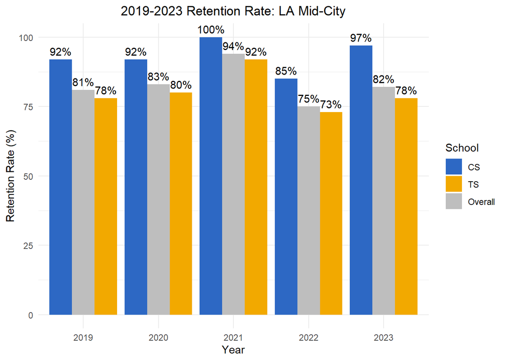

**Number of CS:** 1

**Number of TS:** 4

**Overall Combined Table**

[output not shown]

### Downtown

#### Overall

| School | 2019 | 2020 | 2021 | 2022 | 2023 |
| --- | --- | --- | --- | --- | --- |
| Frank Del Olmo Elementary | 85 | 94 | 83 | 82 | 74 |
| Logan Academy of Global Ecology | 77 | 82 | 75 | 85 | 89 |
| Rosemont Avenue Elementary | 80 | 87 | 60 | 50 | 82 |
| Overall Retention Rate % | 81 | 88 | 73 | 72 | 82 |

#### CS

| School | 2019 | 2020 | 2021 | 2022 | 2023 |
| --- | --- | --- | --- | --- | --- |
| Logan Academy of Global Ecology | 77 | 82 | 75 | 85 | 89 |
| Overall Retention Rate % | 77 | 82 | 75 | 85 | 89 |

#### TS

| School | 2019 | 2020 | 2021 | 2022 | 2023 |
| --- | --- | --- | --- | --- | --- |
| Frank Del Olmo Elementary | 85 | 94 | 83 | 82 | 74 |
| Rosemont Avenue Elementary | 80 | 87 | 60 | 50 | 82 |
| Overall Retention Rate % | 82 | 90 | 72 | 66 | 78 |

#### Graph

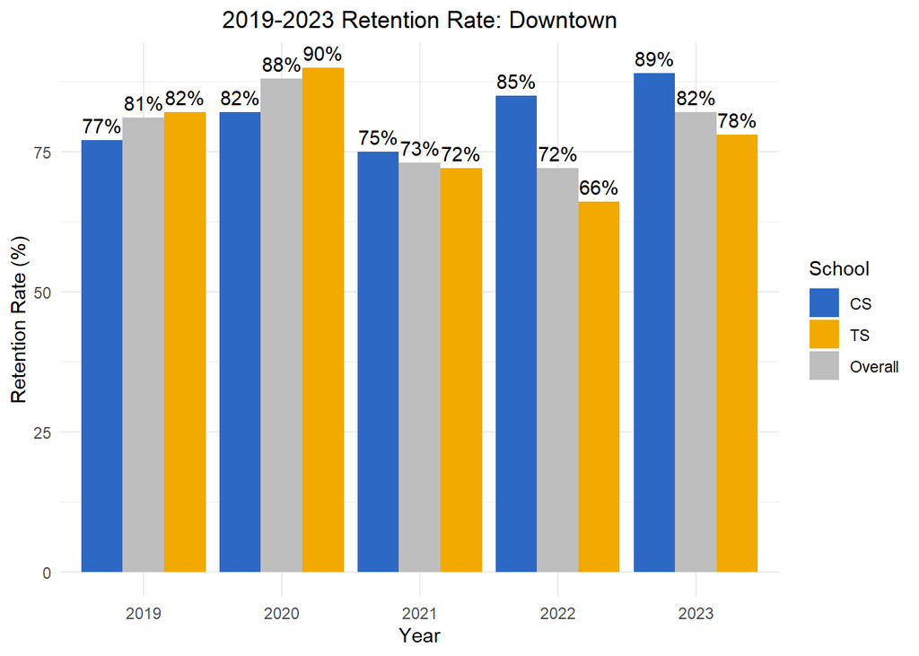

**Number of CS:** 1

**Number of TS:** 2

**Overall Combined Table**

[output not shown]

### Sun Valley

#### Overall

| School | 2019 | 2020 | 2021 | 2022 | 2023 |
| --- | --- | --- | --- | --- | --- |
| Arleta Senior High | 94 | 92 | 88 | 84 | 97 |
| Arminta Street Elementary | 83 | 83 | 100 | 88 | 100 |
| Beachy Avenue Elementary | 85 | 100 | 89 | 85 | 82 |
| Fernangeles Elementary | 91 | 87 | 91 | 94 | 89 |
| John H Francis Polytechnic Senior High | 92 | 93 | 95 | 85 | 91 |
| Julie Korenstein Elementary | 91 | 95 | 80 | 80 | 84 |
| Sharp Avenue Elementary | 81 | 94 | 91 | 84 | 82 |
| Overall Retention Rate % | 88 | 92 | 91 | 86 | 89 |

#### CS

| School | 2019 | 2020 | 2021 | 2022 | 2023 |
| --- | --- | --- | --- | --- | --- |
| John H Francis Polytechnic Senior High | 92 | 93 | 95 | 85 | 91 |
| Sharp Avenue Elementary | 81 | 94 | 91 | 84 | 82 |
| Overall Retention Rate % | 86 | 94 | 93 | 84 | 86 |

#### TS

| School | 2019 | 2020 | 2021 | 2022 | 2023 |
| --- | --- | --- | --- | --- | --- |
| Arleta Senior High | 94 | 92 | 88 | 84 | 97 |
| Arminta Street Elementary | 83 | 83 | 100 | 88 | 100 |
| Beachy Avenue Elementary | 85 | 100 | 89 | 85 | 82 |
| Fernangeles Elementary | 91 | 87 | 91 | 94 | 89 |
| Julie Korenstein Elementary | 91 | 95 | 80 | 80 | 84 |
| Overall Retention Rate % | 89 | 91 | 90 | 86 | 90 |

#### Graph

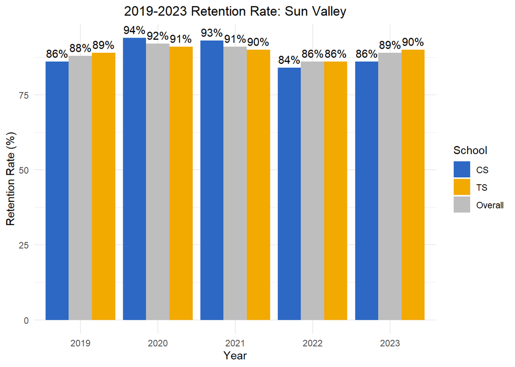

**Number of CS:** 2

**Number of TS:** 5

**Overall Combined Table**

[output not shown]

### Gardena

#### Overall

| School | 2019 | 2020 | 2021 | 2022 | 2023 |
| --- | --- | --- | --- | --- | --- |
| 153rd Street Elementary | 88 | 85 | 88 | 68 | 90 |
| Amestoy Elementary | 93 | 100 | 87 | 85 | 100 |
| Chapman Elementary | 91 | 95 | 90 | 95 | 90 |
| Denker Avenue Elementary | 97 | 97 | 90 | 86 | 95 |
| Purche Avenue Elementary | 84 | 83 | 89 | 76 | 72 |
| Overall Retention Rate % | 91 | 92 | 89 | 82 | 89 |

#### CS

| School | 2019 | 2020 | 2021 | 2022 | 2023 |
| --- | --- | --- | --- | --- | --- |
| Purche Avenue Elementary | 84 | 83 | 89 | 76 | 72 |
| Overall Retention Rate % | 84 | 83 | 89 | 76 | 72 |

#### TS

| School | 2019 | 2020 | 2021 | 2022 | 2023 |
| --- | --- | --- | --- | --- | --- |
| 153rd Street Elementary | 88 | 85 | 88 | 68 | 90 |
| Amestoy Elementary | 93 | 100 | 87 | 85 | 100 |
| Chapman Elementary | 91 | 95 | 90 | 95 | 90 |
| Denker Avenue Elementary | 97 | 97 | 90 | 86 | 95 |
| Overall Retention Rate % | 92 | 94 | 89 | 84 | 94 |

#### Graph

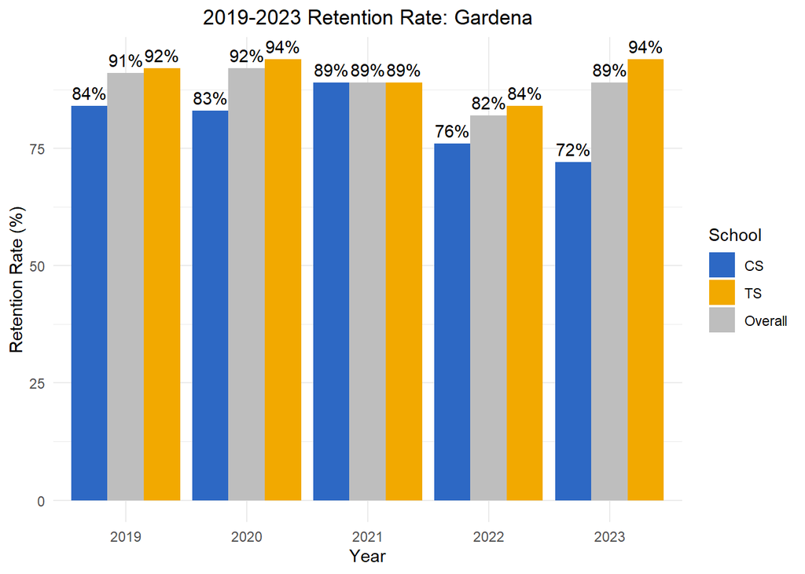

**Number of CS:** 1

**Number of TS:** 4

**Overall Combined Table**

[output not shown]

### South LA

#### Overall

| School | 2019 | 2020 | 2021 | 2022 | 2023 |
| --- | --- | --- | --- | --- | --- |
| 28th Street Elementary | 91 | 97 | 97 | 88 | 100 |
| 9th Street Elementary | 100 | 89 | 69 | 69 | 88 |
| Ricardo Lizarraga Elementary | 82 | 93 | 82 | 84 | 94 |
| Trinity Street Elementary | 78 | 87 | 81 | 94 | 83 |
| Wadsworth Avenue Elementary | 89 | 97 | 92 | 94 | 86 |
| West Vernon Avenue Elementary | 100 | 89 | 94 | 74 | 89 |
| Overall Retention Rate % | 90 | 92 | 86 | 84 | 90 |

#### CS

| School | 2019 | 2020 | 2021 | 2022 | 2023 |
| --- | --- | --- | --- | --- | --- |
| Trinity Street Elementary | 78 | 87 | 81 | 94 | 83 |
| Overall Retention Rate % | 78 | 87 | 81 | 94 | 83 |

#### TS

| School | 2019 | 2020 | 2021 | 2022 | 2023 |
| --- | --- | --- | --- | --- | --- |
| 28th Street Elementary | 91 | 97 | 97 | 88 | 100 |
| 9th Street Elementary | 100 | 89 | 69 | 69 | 88 |
| Ricardo Lizarraga Elementary | 82 | 93 | 82 | 84 | 94 |
| Wadsworth Avenue Elementary | 89 | 97 | 92 | 94 | 86 |
| West Vernon Avenue Elementary | 100 | 89 | 94 | 74 | 89 |
| Overall Retention Rate % | 92 | 93 | 87 | 82 | 91 |

#### Graph

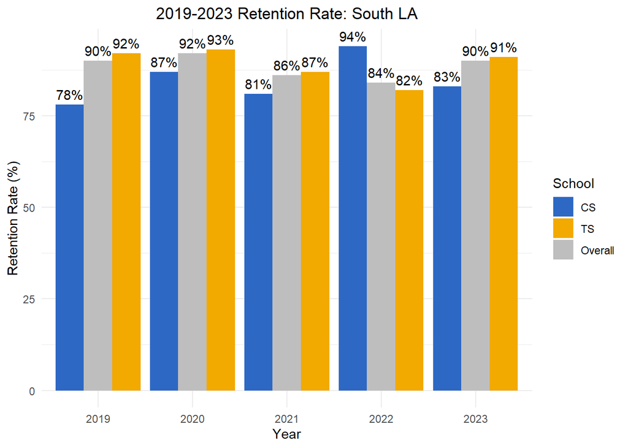

**Number of CS:** 1

**Number of TS:** 5

**Overall Combined Table**

[output not shown]

### Riveria

#### Overall

| School | 2019 | 2020 | 2021 | 2022 | 2023 |
| --- | --- | --- | --- | --- | --- |
| 66th Street Elementary | 92 | 86 | 82 | 92 | 92 |
| Judith F Baca Arts Academy | 100 | 92 | 94 | 92 | 94 |
| McKinley Avenue Elementary | 95 | 89 | 81 | 88 | 89 |
| Miramonte Elementary | 95 | 90 | 90 | 82 | 90 |
| Parmelee Avenue Elementary | 93 | 88 | 97 | 92 | 92 |
| Russell Elementary | 92 | 95 | 74 | 83 | 94 |
| Wisdom Elementary | 95 | 98 | 88 | 90 | 92 |
| Overall Retention Rate % | 95 | 91 | 87 | 88 | 92 |

#### CS

| School | 2019 | 2020 | 2021 | 2022 | 2023 |
| --- | --- | --- | --- | --- | --- |
| Miramonte Elementary | 95 | 90 | 90 | 82 | 90 |
| Overall Retention Rate % | 95 | 90 | 90 | 82 | 90 |

#### TS

| School | 2019 | 2020 | 2021 | 2022 | 2023 |
| --- | --- | --- | --- | --- | --- |
| 66th Street Elementary | 92 | 86 | 82 | 92 | 92 |
| Judith F Baca Arts Academy | 100 | 92 | 94 | 92 | 94 |
| McKinley Avenue Elementary | 95 | 89 | 81 | 88 | 89 |
| Parmelee Avenue Elementary | 93 | 88 | 97 | 92 | 92 |
| Russell Elementary | 92 | 95 | 74 | 83 | 94 |
| Wisdom Elementary | 95 | 98 | 88 | 90 | 92 |
| Overall Retention Rate % | 94 | 91 | 86 | 90 | 92 |

#### Graph

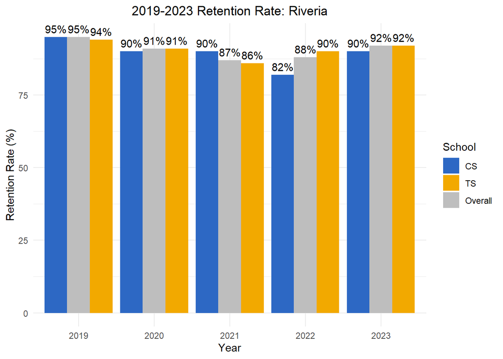

**Number of CS:** 1

**Number of TS:** 6

**Overall Combined Table**

[output not shown]

### South Mid-City

#### Overall

| School | 2019 | 2020 | 2021 | 2022 | 2023 |
| --- | --- | --- | --- | --- | --- |
| Augustus Hawkins Senior High | 85 | 76 | 79 | 54 | 78 |
| Overall Retention Rate % | 85 | 76 | 79 | 54 | 78 |

#### CS

| School | 2019 | 2020 | 2021 | 2022 | 2023 |
| --- | --- | --- | --- | --- | --- |
| Augustus Hawkins Senior High | 85 | 76 | 79 | 54 | 78 |
| Overall Retention Rate % | 85 | 76 | 79 | 54 | 78 |

#### TS

| School | 2019 | 2020 | 2021 | 2022 | 2023 |
| --- | --- | --- | --- | --- | --- |
| NA | NA | NA | NA | NA | NA |

#### Graph

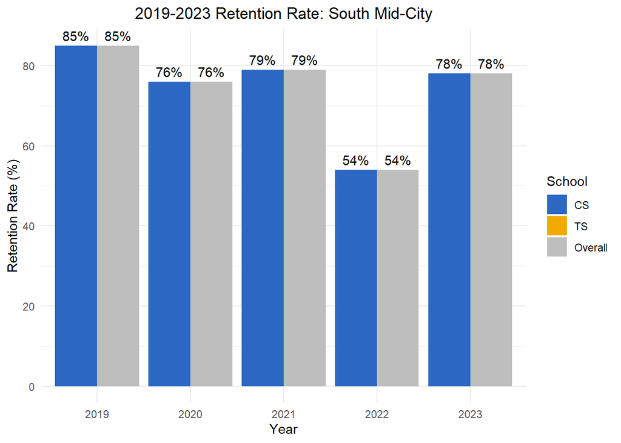

**Number of CS:** 1

**Number of TS:** 0

**Overall Combined Table**

[output not shown]

### Venice

#### Overall

| School | 2019 | 2020 | 2021 | 2022 | 2023 |
| --- | --- | --- | --- | --- | --- |
| Marina Del Rey Middle School | 88 | 72 | 88 | 76 | 72 |
| Mark Twain Middle School | 93 | 90 | 82 | 89 | 82 |
| Venice Senior High | 79 | 88 | 74 | 91 | 90 |
| Overall Retention Rate % | 87 | 83 | 81 | 85 | 81 |

#### CS

| School | 2019 | 2020 | 2021 | 2022 | 2023 |
| --- | --- | --- | --- | --- | --- |
| Marina Del Rey Middle School | 88 | 72 | 88 | 76 | 72 |
| Venice Senior High | 79 | 88 | 74 | 91 | 90 |
| Overall Retention Rate % | 84 | 80 | 81 | 84 | 81 |

#### TS

| School | 2019 | 2020 | 2021 | 2022 | 2023 |
| --- | --- | --- | --- | --- | --- |
| Mark Twain Middle School | 93 | 90 | 82 | 89 | 82 |
| Overall Retention Rate % | 93 | 90 | 82 | 89 | 82 |

#### Graph

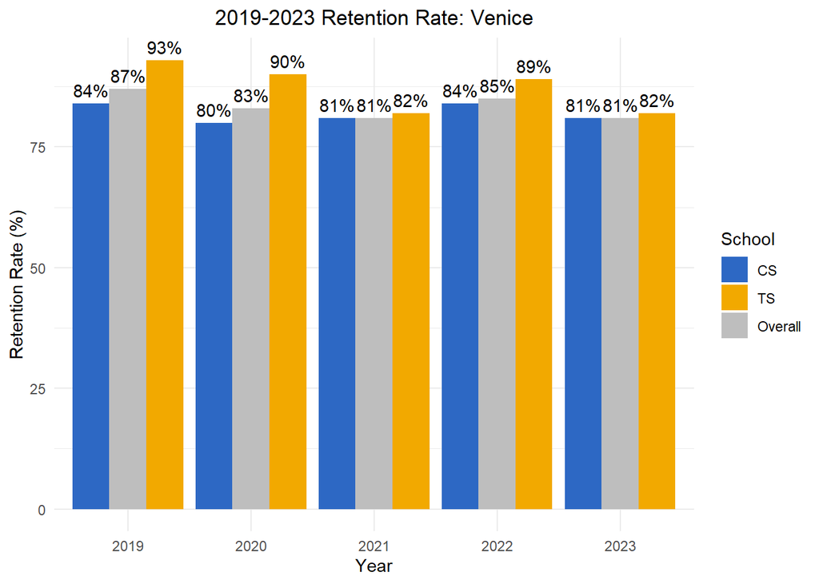

**Number of CS:** 2

**Number of TS:** 1

**Overall Combined Table**

[output not shown]

### Heet

#### Overall

| School | 2019 | 2020 | 2021 | 2022 | 2023 |
| --- | --- | --- | --- | --- | --- |
| 42nd Street Elementary | 58 | 54 | 71 | 75 | 75 |
| 59th Street Elementary | 88 | 78 | 80 | 58 | 88 |
| 74th Street Elementary | 86 | 95 | 78 | 75 | 91 |
| Audubon Middle School | 57 | 83 | 79 | 57 | 76 |
| Coliseum Street Elementary | 80 | 100 | 83 | 85 | 87 |
| Hillcrest Drive Elementary | 82 | 96 | 89 | 78 | 81 |
| Manhattan Place Elementary | 63 | 65 | 77 | 56 | 62 |
| Susan Miller Dorsey Senior High | 63 | 76 | 88 | 75 | 80 |
| Young Empowered Scholars Academy | 88 | 78 | 85 | 75 | 77 |
| Overall Retention Rate % | 74 | 81 | 81 | 70 | 80 |

#### CS

| School | 2019 | 2020 | 2021 | 2022 | 2023 |
| --- | --- | --- | --- | --- | --- |
| 74th Street Elementary | 86 | 95 | 78 | 75 | 91 |
| Audubon Middle School | 57 | 83 | 79 | 57 | 76 |
| Hillcrest Drive Elementary | 82 | 96 | 89 | 78 | 81 |
| Susan Miller Dorsey Senior High | 63 | 76 | 88 | 75 | 80 |
| Overall Retention Rate % | 72 | 88 | 84 | 71 | 82 |

#### TS

| School | 2019 | 2020 | 2021 | 2022 | 2023 |
| --- | --- | --- | --- | --- | --- |
| 42nd Street Elementary | 58 | 54 | 71 | 75 | 75 |
| 59th Street Elementary | 88 | 78 | 80 | 58 | 88 |
| Coliseum Street Elementary | 80 | 100 | 83 | 85 | 87 |
| Manhattan Place Elementary | 63 | 65 | 77 | 56 | 62 |
| Young Empowered Scholars Academy | 88 | 78 | 85 | 75 | 77 |
| Overall Retention Rate % | 75 | 75 | 79 | 70 | 78 |

#### Graph

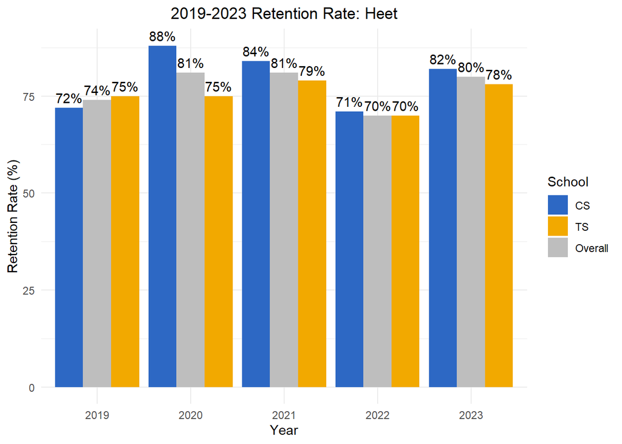

**Number of CS:** 4

**Number of TS:** 5

**Overall Combined Table**

[output not shown]

### Macarthur Park

#### Overall

| School | 2019 | 2020 | 2021 | 2022 | 2023 |
| --- | --- | --- | --- | --- | --- |
| Harold McAlister High School CYESIS | 90 | 78 | 100 | 90 | 67 |
| Miguel Contreras Learning Complex - Acdemic Ldrshp Community | 76 | 91 | 83 | 75 | 69 |
| Miguel Contreras Learning Complex - Business and Tourism | 81 | 95 | 90 | 95 | 87 |
| Miguel Contreras Learning Complex - LA Sch of Global Studies | 94 | 76 | 94 | 79 | 83 |
| Miguel Contreras Learning Complex - School of Social Justice | 95 | 90 | 86 | 91 | 79 |
| Overall Retention Rate % | 87 | 86 | 91 | 86 | 77 |

#### CS

| School | 2019 | 2020 | 2021 | 2022 | 2023 |
| --- | --- | --- | --- | --- | --- |
| Miguel Contreras Learning Complex - Acdemic Ldrshp Community | 76 | 91 | 83 | 75 | 69 |
| Miguel Contreras Learning Complex - LA Sch of Global Studies | 94 | 76 | 94 | 79 | 83 |
| Overall Retention Rate % | 85 | 84 | 88 | 77 | 76 |

#### TS

| School | 2019 | 2020 | 2021 | 2022 | 2023 |
| --- | --- | --- | --- | --- | --- |
| Harold McAlister High School CYESIS | 90 | 78 | 100 | 90 | 67 |
| Miguel Contreras Learning Complex - Business and Tourism | 81 | 95 | 90 | 95 | 87 |
| Miguel Contreras Learning Complex - School of Social Justice | 95 | 90 | 86 | 91 | 79 |
| Overall Retention Rate % | 89 | 88 | 92 | 92 | 78 |

#### Graph

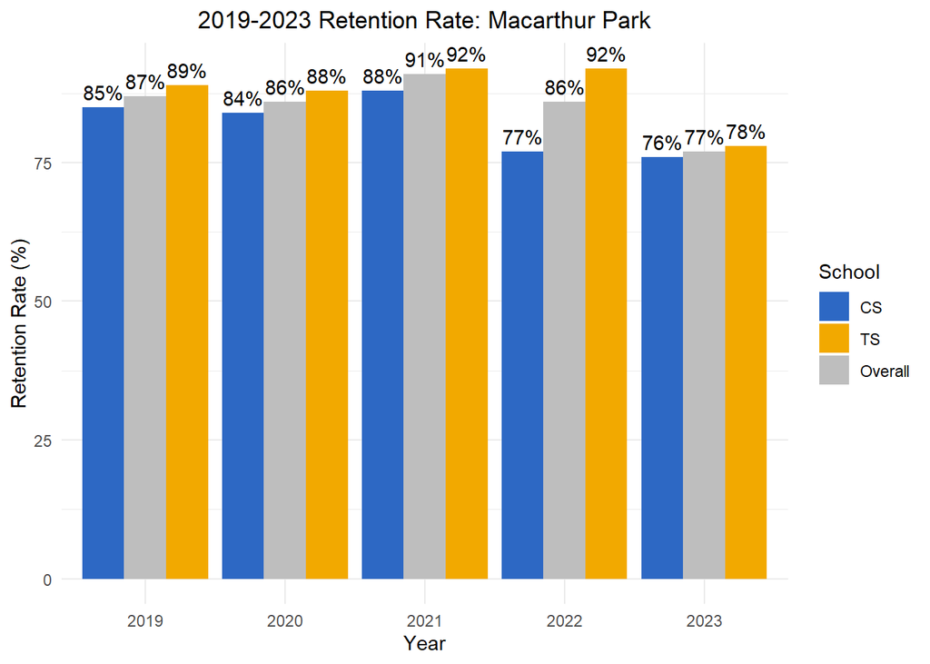

**Number of CS:** 2

**Number of TS:** 3

**Overall Combined Table**

| School | 2019 | 2020 | 2021 | 2022 | 2023 |
| --- | --- | --- | --- | --- | --- |
| CS Overall Retention Rate | 85 | 84 | 88 | 77 | 76 |
| TS Overall Retention Rate | 89 | 88 | 92 | 92 | 78 |
| Combined Overall Retention Rate | 87 | 86 | 91 | 86 | 77 |

### Historic Central Ave

#### Overall

| School | 2019 | 2020 | 2021 | 2022 | 2023 |
| --- | --- | --- | --- | --- | --- |
| Carver MS | NaN | 72 | 86 | 77 | 79 |
| George Washington Carver Middle School | 0 | NaN | NaN | NaN | NaN |
| Los Angeles Academy Middle School | 82 | 91 | 95 | 79 | 83 |
| Overall Retention Rate % | 27 | 54 | 60 | 52 | 54 |

#### CS

| School | 2019 | 2020 | 2021 | 2022 | 2023 |
| --- | --- | --- | --- | --- | --- |
| Carver MS | NaN | 72 | 86 | 77 | 79 |
| Overall Retention Rate % | 0 | 72 | 86 | 77 | 79 |

#### TS

| School | 2019 | 2020 | 2021 | 2022 | 2023 |
| --- | --- | --- | --- | --- | --- |
| George Washington Carver Middle School | 0 | NaN | NaN | NaN | NaN |
| Los Angeles Academy Middle School | 82 | 91 | 95 | 79 | 83 |
| Overall Retention Rate % | 41 | 46 | 48 | 40 | 42 |

#### Graph

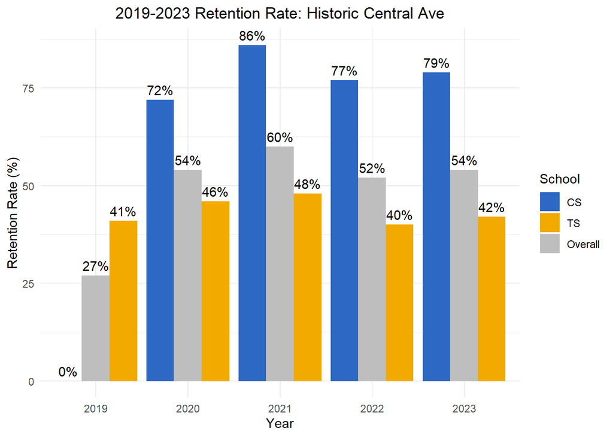

**Number of CS:** 1

**Number of TS:** 2

**Overall Combined Table**

[output not shown]

### Fremont

#### Overall

| School | 2019 | 2020 | 2021 | 2022 | 2023 |
| --- | --- | --- | --- | --- | --- |
| 107th Street Elementary | 81 | 86 | 79 | 89 | 84 |
| 75th Street Elementary | 87 | 73 | 87 | 86 | 85 |
| 93rd Street Elementary | 88 | 85 | 84 | 83 | 80 |
| 99th Street Elementary | 79 | 91 | 71 | 77 | 69 |
| Figueroa Street Elementary | 87 | 95 | 95 | 83 | 96 |
| Florence Griffith Joyner Elementary | 85 | 76 | 83 | 48 | 74 |
| South Park Elementary | 93 | 89 | 91 | 88 | 96 |
| Overall Retention Rate % | 86 | 85 | 84 | 79 | 83 |

#### CS

| School | 2019 | 2020 | 2021 | 2022 | 2023 |
| --- | --- | --- | --- | --- | --- |
| 93rd Street Elementary | 88 | 85 | 84 | 83 | 80 |
| Overall Retention Rate % | 88 | 85 | 84 | 83 | 80 |

#### TS

| School | 2019 | 2020 | 2021 | 2022 | 2023 |
| --- | --- | --- | --- | --- | --- |
| 107th Street Elementary | 81 | 86 | 79 | 89 | 84 |
| 75th Street Elementary | 87 | 73 | 87 | 86 | 85 |
| 99th Street Elementary | 79 | 91 | 71 | 77 | 69 |
| Figueroa Street Elementary | 87 | 95 | 95 | 83 | 96 |
| Florence Griffith Joyner Elementary | 85 | 76 | 83 | 48 | 74 |
| South Park Elementary | 93 | 89 | 91 | 88 | 96 |
| Overall Retention Rate % | 85 | 85 | 84 | 78 | 84 |

#### Graph

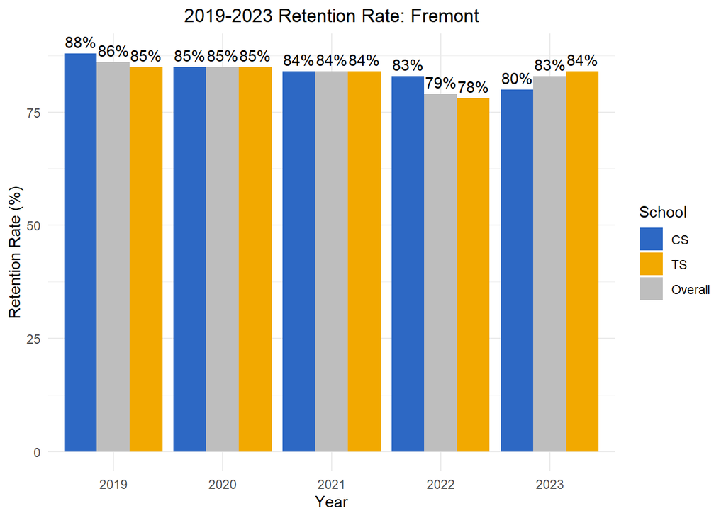

**Number of CS:** 1

**Number of TS:** 6

**Overall Combined Table**

[output not shown]

### Carson

#### Overall

| School | 2019 | 2020 | 2021 | 2022 | 2023 |
| --- | --- | --- | --- | --- | --- |
| Bonita Street Elementary | 88 | 95 | 87 | 92 | 80 |
| Caroldale Learning Community | 95 | 89 | 89 | 90 | 82 |
| Catskill Avenue Elementary | 96 | 92 | 93 | 96 | 94 |
| Dolores Street Elementary | 94 | 93 | 93 | 92 | 93 |
| Glenn Hammond Curtiss Middle School | 58 | 92 | 92 | 67 | 80 |
| Overall Retention Rate % | 86 | 92 | 91 | 87 | 86 |

#### CS

| School | 2019 | 2020 | 2021 | 2022 | 2023 |
| --- | --- | --- | --- | --- | --- |
| Catskill Avenue Elementary | 96 | 92 | 93 | 96 | 94 |
| Overall Retention Rate % | 96 | 92 | 93 | 96 | 94 |

#### TS

| School | 2019 | 2020 | 2021 | 2022 | 2023 |
| --- | --- | --- | --- | --- | --- |
| Bonita Street Elementary | 88 | 95 | 87 | 92 | 80 |
| Caroldale Learning Community | 95 | 89 | 89 | 90 | 82 |
| Dolores Street Elementary | 94 | 93 | 93 | 92 | 93 |
| Glenn Hammond Curtiss Middle School | 58 | 92 | 92 | 67 | 80 |
| Overall Retention Rate % | 84 | 92 | 90 | 85 | 84 |

#### Graph

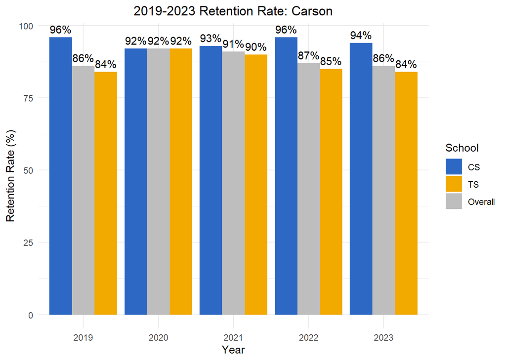

**Number of CS:** 1

**Number of TS:** 4

**Overall Combined Table**

[output not shown]

### Boyle Heights

#### Overall

| School | 2019 | 2020 | 2021 | 2022 | 2023 |
| --- | --- | --- | --- | --- | --- |
| 1st Street Elementary | 82 | 87 | 88 | 84 | 85 |
| 2nd Street Elementary | 80 | 88 | 94 | 75 | 88 |
| Carmen Lomas Garza Primary Center | 78 | 86 | 86 | 88 | 89 |
| Euclid Avenue Elementary | 90 | 87 | 84 | 92 | 84 |
| Felicitas And Gonzalo Mendez Senior High | 96 | 95 | 93 | 88 | 79 |
| Malabar Street Elementary | 93 | 86 | 77 | 82 | 87 |
| Soto Street Elementary | 87 | 94 | 82 | 94 | 89 |
| Theodore Roosevelt Senior High | 88 | 68 | 95 | 93 | 89 |
| Overall Retention Rate % | 87 | 86 | 87 | 87 | 86 |

#### CS

| School | 2019 | 2020 | 2021 | 2022 | 2023 |
| --- | --- | --- | --- | --- | --- |
| Euclid Avenue Elementary | 90 | 87 | 84 | 92 | 84 |
| Felicitas And Gonzalo Mendez Senior High | 96 | 95 | 93 | 88 | 79 |
| Overall Retention Rate % | 93 | 91 | 88 | 90 | 82 |

#### TS

| School | 2019 | 2020 | 2021 | 2022 | 2023 |
| --- | --- | --- | --- | --- | --- |
| 1st Street Elementary | 82 | 87 | 88 | 84 | 85 |
| 2nd Street Elementary | 80 | 88 | 94 | 75 | 88 |
| Carmen Lomas Garza Primary Center | 78 | 86 | 86 | 88 | 89 |
| Malabar Street Elementary | 93 | 86 | 77 | 82 | 87 |
| Soto Street Elementary | 87 | 94 | 82 | 94 | 89 |
| Theodore Roosevelt Senior High | 88 | 68 | 95 | 93 | 89 |
| Overall Retention Rate % | 85 | 85 | 87 | 86 | 88 |

#### Graph

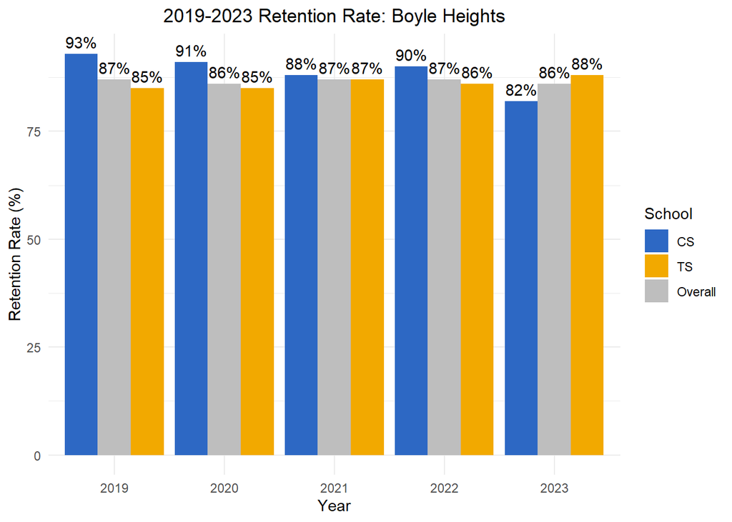

**Number of CS:** 2

**Number of TS:** 6

**Overall Combined Table**

| School | 2019 | 2020 | 2021 | 2022 | 2023 |
| --- | --- | --- | --- | --- | --- |
| CS Overall Retention Rate | 93 | 91 | 88 | 90 | 82 |
| TS Overall Retention Rate | 85 | 85 | 87 | 86 | 88 |
| Combined Overall Retention Rate | 87 | 86 | 87 | 87 | 86 |

### Lincoln Heights El Sereno

#### Overall

| School | 2019 | 2020 | 2021 | 2022 | 2023 |
| --- | --- | --- | --- | --- | --- |
| Abraham Lincoln Senior High | 83 | 89 | 92 | 80 | 80 |
| El Sereno Elementary | 83 | 88 | 81 | 94 | 75 |
| Farmdale Elementary | 81 | 85 | 91 | 83 | 100 |
| Multnomah Street Elementary | 61 | 91 | 82 | 55 | 83 |
| Sierra Park Elementary | 90 | 90 | 73 | 95 | 86 |
| Woodrow Wilson Senior High | 86 | 82 | 93 | 84 | 91 |
| Overall Retention Rate % | 81 | 88 | 85 | 82 | 86 |

#### CS

| School | 2019 | 2020 | 2021 | 2022 | 2023 |
| --- | --- | --- | --- | --- | --- |
| Farmdale Elementary | 81 | 85 | 91 | 83 | 100 |
| Woodrow Wilson Senior High | 86 | 82 | 93 | 84 | 91 |
| Overall Retention Rate % | 84 | 84 | 92 | 84 | 96 |

#### TS

| School | 2019 | 2020 | 2021 | 2022 | 2023 |
| --- | --- | --- | --- | --- | --- |
| Abraham Lincoln Senior High | 83 | 89 | 92 | 80 | 80 |
| El Sereno Elementary | 83 | 88 | 81 | 94 | 75 |
| Multnomah Street Elementary | 61 | 91 | 82 | 55 | 83 |
| Sierra Park Elementary | 90 | 90 | 73 | 95 | 86 |
| Overall Retention Rate % | 79 | 90 | 82 | 81 | 81 |

#### Graph

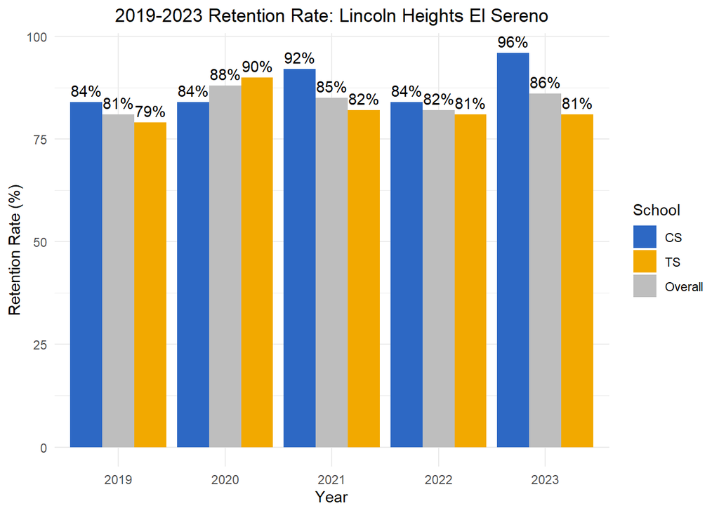

**Number of CS:** 2

**Number of TS:** 4

**Overall Combined Table**

[output not shown]